# Analyzing Female Genital Mutilation Globally

Janessa McIlnay

April 22, 2025

## Background

Female genital mutilation is practiced in cultures that believe in removing sexual desire of women. They believe it is a man’s right to marry a virgin. To enforce the chastity of women, the clitoris of young girls is removed, usually by an untrained individual and in unsanitary conditions, and her labia majora is typically sewn shut. This practice is sickening, but still happens to 3 million girls annually, even in the US and to girls as young as 3 years old. It is most prevalent in the Middle East, Africa, and Asia.

FGM is a violation of human rights. It causes extreme pain and irreversible damage. Some side effects include scarring, sexual dysfunction, childbirth issues, depression, and anxiety.

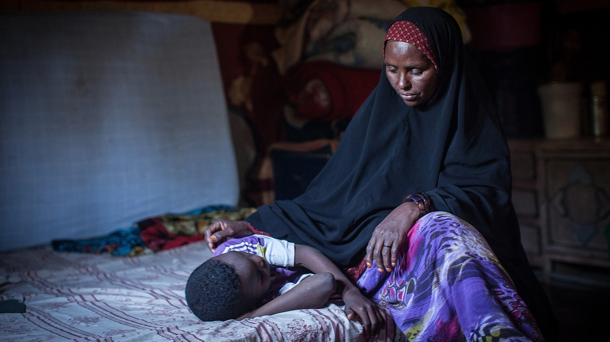

Image1

## Data

The data analyzed for this project was collected by the [unicef](https://data.unicef.org/topic/child-protection/female-genital-mutilation/) which aims to improve and protect the rights of children worldwide. The data was last updated in March 2024 and includes women aged 15-49.

```r
# Load necessary libraries
library(tidyverse)
library(ggplot2)
library(caret)
library(readxl)
library(dplyr)
library(tidyr)
library(easystats)
```

## Cleaning the Data

### Before

```r
raw_data <- read_excel('media/XLS_FGM-Women-prevalence-database_Mar-2024.xlsx',
                       sheet = "Women FGM", skip = 6)
print(raw_data)
```

```
## # A tibble: 233 × 19
##    `Countries and areas` FGM prevalence among gir…¹ ...3  FGM prevalence among…²
##    <chr>                 <chr>                      <chr> <chr>
##  1 <NA>                  <NA>                       <NA>  Residence
##  2 <NA>                  <NA>                       <NA>  Urban
##  3 <NA>                  <NA>                       <NA>  <NA>
##  4 Afghanistan           -                          <NA>  -
##  5 Albania               -                          <NA>  -
##  6 Algeria               -                          <NA>  -
##  7 Andorra               -                          <NA>  -
##  8 Angola                -                          <NA>  -
##  9 Anguilla              -                          <NA>  -
## 10 Antigua and Barbuda   -                          <NA>  -
## # ℹ 223 more rows
## # ℹ abbreviated names: ¹`FGM prevalence among girls and women (%)`,
## #   ²`FGM prevalence among girls and women aged 15 to 49 years, by residence and wealth quintile (%)\r\n(2014-2022)*`
## # ℹ 15 more variables: ...5 <chr>, ...6 <chr>, ...7 <chr>, ...8 <chr>,
## #   ...9 <chr>, ...10 <chr>, ...11 <chr>, ...12 <chr>, ...13 <chr>,
## #   ...14 <chr>, ...15 <chr>, ...16 <chr>, ...17 <chr>, `Reference year` <chr>,
## #   `Data source` <chr>
```

The data is super messy! Here’s what I did to clean it up.

### After

```r
clean_data <- raw_data[-c(1:3), ]

# Renaming the columns
colnames(clean_data) <- c(
  "Country", "Prevalence_Total", "NA1",
  "Residence_Urban", "NA2", "Residence_Rural",
  "NA3", "Wealth_Poorest", "NA4",
  "Wealth_Second", "NA5", "Wealth_Middle", "NA6",
  "Wealth_Fourth", "NA7", "Wealth_Richest", "NA8", "Year", "Source"
)

# Dropping NA
clean_data <- clean_data %>%
  select(-starts_with("NA"))


# Remove rows with all NAs
clean_data <- clean_data %>% filter(!if_all(everything(), is.na))
clean_data2 <- clean_data %>%
  mutate(across(where(is.character), ~na_if(.x, "-"))) %>%
  mutate(across(c(Prevalence_Total, Residence_Urban, Residence_Rural,
                  Wealth_Poorest, Wealth_Second, Wealth_Middle,
                  Wealth_Fourth, Wealth_Richest), as.numeric))
FGM <- clean_data2 %>%
  filter(!if_all(c(Prevalence_Total, Residence_Urban, Residence_Rural,
                   Wealth_Poorest, Wealth_Second, Wealth_Middle,
                   Wealth_Fourth, Wealth_Richest), is.na))

FGM_long <- FGM %>%
  pivot_longer(cols = starts_with("Wealth_"), names_to = "Wealth_Group", values_to = "FGM_Prevalence")


FGM_long$Wealth_Group <- factor(FGM_long$Wealth_Group,
                                 levels = c("Wealth_Poorest", "Wealth_Second", "Wealth_Middle",
                                            "Wealth_Fourth", "Wealth_Richest"),
                                 labels = c("Poorest", "Second", "Middle", "Fourth", "Richest"))
print(FGM_long)
```

```
## # A tibble: 165 × 8
##    Country      Prevalence_Total Residence_Urban Residence_Rural Year  Source
##    <chr>                   <dbl>           <dbl>           <dbl> <chr> <chr>
##  1 Benin                     9.2             5.2            13.1 2014  MICS 2014
##  2 Benin                     9.2             5.2            13.1 2014  MICS 2014
##  3 Benin                     9.2             5.2            13.1 2014  MICS 2014
##  4 Benin                     9.2             5.2            13.1 2014  MICS 2014
##  5 Benin                     9.2             5.2            13.1 2014  MICS 2014
##  6 Burkina Faso             56.1            50.2            58.9 2021  DHS 2021
##  7 Burkina Faso             56.1            50.2            58.9 2021  DHS 2021
##  8 Burkina Faso             56.1            50.2            58.9 2021  DHS 2021
##  9 Burkina Faso             56.1            50.2            58.9 2021  DHS 2021
## 10 Burkina Faso             56.1            50.2            58.9 2021  DHS 2021
## # ℹ 155 more rows
## # ℹ 2 more variables: Wealth_Group <fct>, FGM_Prevalence <dbl>
```

Much better! Now let’s analyze it.

## Finding Relationships Between Wealth and Prevalence of FGM

```r
mod1 <- glm(data = FGM,
            formula = Prevalence_Total ~ Residence_Rural)

mod2 <- glm(data = FGM,
            formula = Prevalence_Total ~ Residence_Rural * Wealth_Poorest)

mod3 <- glm(data = FGM,
            formula = Prevalence_Total ~ Residence_Urban)
performance(mod3)
```

| AIC | AICc | BIC | R2 | RMSE | Sigma |
| --- | --- | --- | --- | --- | --- |
| 186.6411 | 187.4982 | 191.0383 | 0.985135 | 4.069737 | 4.203206 |

```r
model_multi <- lm(Prevalence_Total ~ Wealth_Second + Wealth_Middle + Wealth_Fourth + Wealth_Richest, data = FGM)
summary(model_multi)
```

```
##
## Call:
## lm(formula = Prevalence_Total ~ Wealth_Second + Wealth_Middle +
##     Wealth_Fourth + Wealth_Richest, data = FGM)
##
## Residuals:
##      Min       1Q   Median       3Q      Max
## -1.54671 -0.33966  0.05185  0.42555  1.47501
##
## Coefficients:
##                Estimate Std. Error t value Pr(>|t|)
## (Intercept)     0.23990    0.23593   1.017 0.318265
## Wealth_Second   0.57976    0.04161  13.934 7.56e-14 ***
## Wealth_Middle  -0.05685    0.05253  -1.082 0.288695
## Wealth_Fourth   0.23435    0.05285   4.434 0.000139 ***
## Wealth_Richest  0.24203    0.03096   7.816 2.10e-08 ***
## ---
## Signif. codes:  0 '***' 0.001 '**' 0.01 '*' 0.05 '.' 0.1 ' ' 1
##
## Residual standard error: 0.8019 on 27 degrees of freedom
##   (1 observation deleted due to missingness)
## Multiple R-squared:  0.9995, Adjusted R-squared:  0.9994
## F-statistic: 1.291e+04 on 4 and 27 DF,  p-value: < 2.2e-16
```

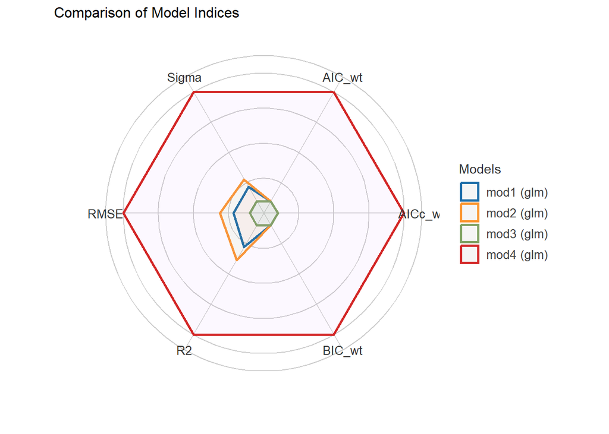

```r
mod4 <- glm(Prevalence_Total ~ Residence_Urban + Residence_Rural +
              Wealth_Poorest + Wealth_Second + Wealth_Middle,
            data = FGM)

compare_performance(mod1, mod2, mod3, mod4) %>% plot()
```

It looks like model 4 is the best at predicting correlation between factors. Let’s see how wealth affects FGM prevalence.

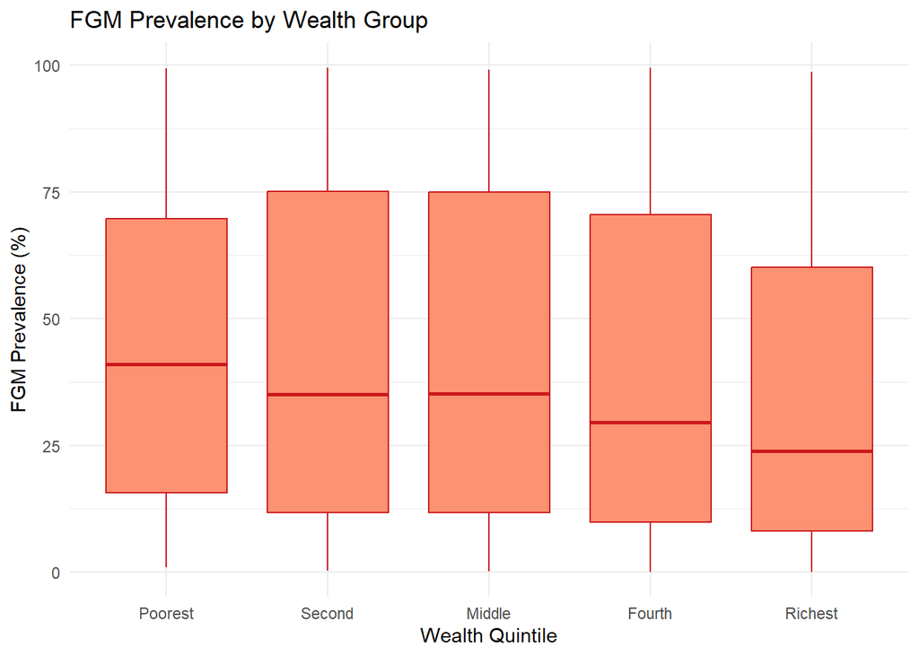

```r
ggplot(FGM_long, aes(x = Wealth_Group, y = FGM_Prevalence)) +
  geom_boxplot(fill = "#FC9272", color = "#CB181D") +
  labs(title = "FGM Prevalence by Wealth Group",
       x = "Wealth Quintile",
       y = "FGM Prevalence (%)") +
  theme_minimal()
```

[figure not shown]

```r
top_country <- FGM %>%
  filter(!is.na(Prevalence_Total)) %>%
  arrange(desc(Prevalence_Total)) %>%
  slice(1)

print(top_country)
```

```
## # A tibble: 1 × 11
##   Country Prevalence_Total Residence_Urban Residence_Rural Wealth_Poorest
##   <chr>              <dbl>           <dbl>           <dbl>          <dbl>
## 1 Somalia             99.2              99            99.4           99.3
## # ℹ 6 more variables: Wealth_Second <dbl>, Wealth_Middle <dbl>,
## #   Wealth_Fourth <dbl>, Wealth_Richest <dbl>, Year <chr>, Source <chr>
```

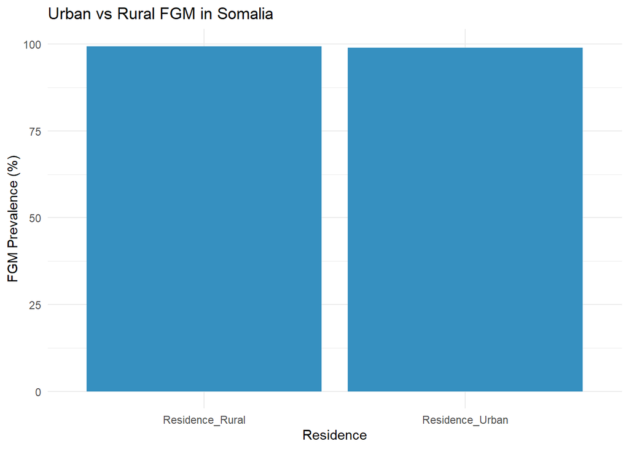

```r
top_country_urban_rural <- FGM %>%
  filter(Country == top_country$Country) %>%
  select(Residence_Urban, Residence_Rural) %>%
  pivot_longer(cols = everything(), names_to = "Residence", values_to = "FGM_Prevalence")

ggplot(top_country_urban_rural, aes(x = Residence, y = FGM_Prevalence)) +
  geom_col(fill = "#3690C0") +
  labs(title = paste("Urban vs Rural FGM in", top_country$Country),
       x = "Residence",
       y = "FGM Prevalence (%)") +
  theme_minimal()
```